# OD Bath

Blaise Kelly

29/05/2022

## Introduction

Data from the 2011 UK census data is queried using the Propensity to Cycle Tool (pct) R package. Origin Destination (OD) matrices are created and ‘jittered’ using the ODjitter R package.

## area of interest

```
## Creating centroids representing desire line start and end points.
```

[interactive chart not shown]

Import the census zones from the pct data from pct package and intersect with area of interest

[interactive chart not shown]

Download Origin Destination (OD) data for zones from LSOA data store. Generate OD desire lines.

[output not shown]

[interactive chart not shown]

Using the osrm R package an estimated route is generated for each car unique OD combination and the journeys assigned. The routes are then combined using the overline function from the stplanr R package

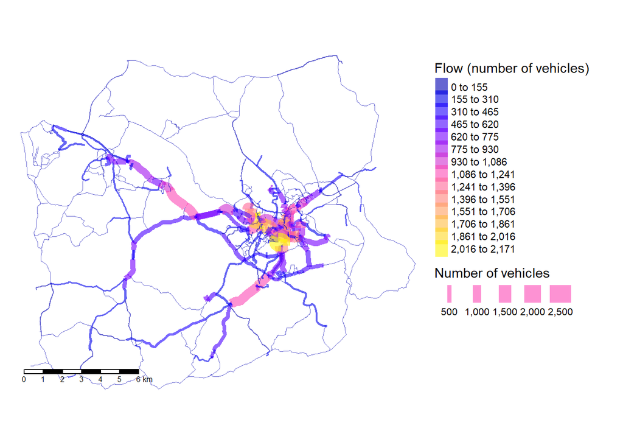

Assuming people start from the centre of a zone can seem like an insignificant simplification when looking at a large area, however, looking more closely at the possibilities for start and end points within a zone and the effect they can have shows it can make a big difference to the likely route someone will take.

Using zone E01014479, which will be called ‘zone A’ as an example below, every journey could theoretically start or finish at any point in the zone. However, even if someone starts from the middle of a field they will not be able to begin driving until they reach a road. Similarly it is also quite likely journeys will start and end at buildings. For privacy and data simplification reasons the census data is not available at household level, so knowing where in a zone a journey starts or ends is not possible.

[interactive chart not shown]

Taking zone E01014479 as ‘zone A’ and E01014482 as ‘zone B’ as example OD pairs. The possible start and end points, if the road network is split into 5 metre uniform points are shown below.

Generating routes between these different pairs the difference start and finish point makes on a journey is shown below, by selecting 4 different route options.

[output not shown]

[output not shown]

[interactive chart not shown]